# Task

A. Lena Bauer

10. November 2020

## required packages

```r
library(ggplot2)
```

## YAML header

1. Add your full name and date to the RMarkdown document in the YAML header

done easily

## Plot the famous *Iris* data

2. Here, add a scatter plot of the iris data set depicting Sepal.Length and Sepal.Width variables and print the figure and the code snippet.

how to make *iris* appear in italic in the title?

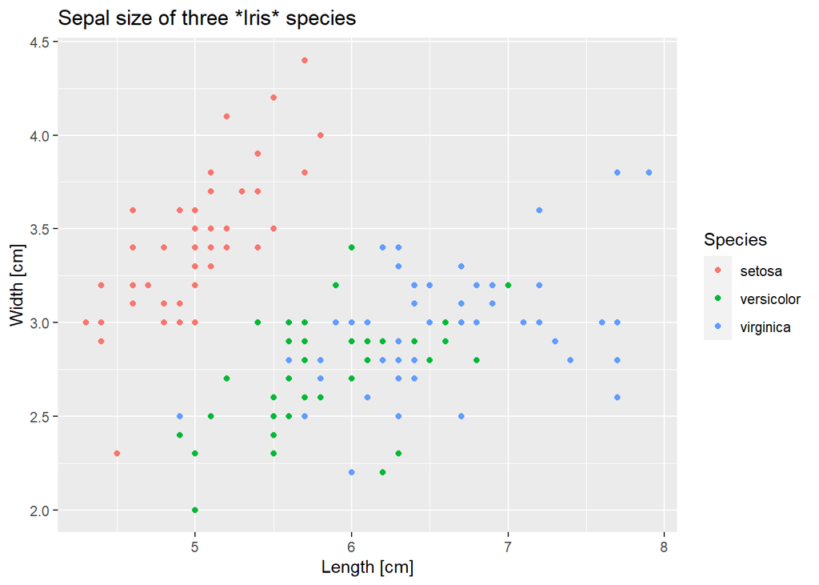

```r
ggplot(iris, aes(x=Sepal.Length, y=Sepal.Width, color=Species)) +
geom_point()+
  ggtitle("Sepal size of three *Iris* species") +
labs(
x="Length [cm]",
y="Width [cm]")
```

## Image

3. Here, add the file git_intro/markdown_meme.jpg to the document

HINT: If this wasn’t covered in the course, just google it ;)

using the url from github, no picture was added correctly. Maybe, because you need a permission (login), although i was logged in. So, i inserted another picture for the first step. The idea comes from: https://stackoverflow.com/questions/28912868/how-to-insert-image-from-url-in-markdown

[figure not shown]

another cat

so here the meme downloaded to my hard drive and inserted afterwards

[figure not shown]

another meme

## Formula

4. Here, add a formula which calculates the Toxic Unit of a concentration (ci) and and EC50 value together with the corresponding text (see Markdown slides).

$$sumTU = log10 \left(\sum_{i=1}^n \frac{c_i}{EC_{50_i}} \right)$$

where
$$c_i$$
is the concentration of the pesticide *i* and
$$EC_{50_i}$$
is the concentration of pesticide
$$i$$
at which 50 % of the test organisms (*Daphnia magna*) were affected.

would had been so nice, but this looks ugly.. ok, lets do it like this

where *c<sub>i</sub>* is the concentration of the pesticide *i* and EC<sub>*50i*</sub> is the concentration of pesticide *i* at which 50% of the test organisms (*Daphnia magna*) were affected.

## Other

5. Add a table of contents to the document. done easily
6. Add a link pointing to the GitHub repository of the course here.

If you want to know more, don’t klick [here](https://olat.vcrp.de/auth/RepositoryEntry/2835448345/CourseNode/102608021997477), because you already know this!